# PCA alternativo con variables transformadas (documento de respaldo)

Coffee Quality Institute — análisis de sensibilidad a la asimetría

Juan Sebastian

21 de septiembre de 2026

> **Qué es este documento.** El informe principal (`informe_taller_pca.Rmd`, secciones 3.1–3.2) detectó que `Moisture`, `Category.One.Defects` y `Category.Two.Defects` están sesgadas, y probó a corregir ese sesgo con una transformación de Yeo-Johnson antes de PCA. Al estimar el parámetro $\lambda$ por máxima verosimilitud, solo `Category.Two.Defects` obtuvo un ajuste estable ($\lambda \approx -0.22$); `Moisture` y `Category.One.Defects` resultaron estar **infladas en cero** (174/1070 lotes con `Moisture = 0`, la mayoría con `Category.One.Defects = 0`) — un problema de calidad de datos que una transformación de potencia no corrige, no una asimetría genuina. La decisión para la entrega fue **mantener el PCA sin transformar** como el oficial, porque PC1 (el hallazgo principal) resultó ser completamente insensible a la corrección. Este documento existe como **respaldo**: repite el análisis completo de PCA transformando únicamente `Category.Two.Defects` — la única variable donde la transformación está bien fundamentada — listo para presentarse si se pide adoptar esa versión en lugar de la oficial.

# 1. Datos y transformación

Mismo conjunto de datos y mismo tratamiento que el informe principal (1070 lotes, 14 variables). La única diferencia es que, antes de estandarizar, se aplica una transformación de Yeo-Johnson a `Category.Two.Defects`, con el $\lambda$ estimado por máxima verosimilitud en la sección 3.2 del informe principal:

```r
library(dplyr)

yeojohnson_transform <- function(x, lambda) {
  if (lambda != 0) ((x + 1)^lambda - 1) / lambda else log(x + 1)
}
yeojohnson_loglik <- function(lambda, x) {
  y <- yeojohnson_transform(x, lambda)
  -length(x) / 2 * log(var(y)) + (lambda - 1) * sum(log(x + 1))
}
yeojohnson_fit <- function(x) {
  optimize(yeojohnson_loglik, interval = c(-5, 5), x = x, maximum = TRUE)$maximum
}

data <- read.csv("../data/arabica_data_cleaned.csv")

vars_cuantitativas <- c("Aroma", "Flavor", "Aftertaste", "Acidity", "Body",
                         "Balance", "Uniformity", "Clean.Cup", "Sweetness",
                         "Cupper.Points", "Moisture", "Category.One.Defects",
                         "Category.Two.Defects", "altitude_mean_meters")

data_f <- data %>%
  filter(is.na(altitude_mean_meters) | (altitude_mean_meters > 0 & altitude_mean_meters <= 3000)) %>%
  filter(!is.na(altitude_mean_meters))

datos <- data_f %>% select(all_of(vars_cuantitativas))

lambda_c2 <- yeojohnson_fit(datos$Category.Two.Defects)
lambda_c2   # ~ -0.217
```

```
## [1] -0.2168494
```

```r
datos_t <- datos
datos_t$Category.Two.Defects <- yeojohnson_transform(datos$Category.Two.Defects, lambda_c2)
```

Las otras 13 variables se dejan sin transformar. `Moisture` y `Category.One.Defects` no se corrigen por la razón ya explicada (inflación en cero, no asimetría corregible); las demás no muestran un sesgo que ameritara la corrección (sección 3.1 del informe principal).

# 2. PCA sobre las variables transformadas

Mismo procedimiento que la sección 5 del informe principal: estandarizar (`center = TRUE, scale. = TRUE`) y diagonalizar $R$.

```r
pca_t <- prcomp(datos_t, center = TRUE, scale. = TRUE)
summary(pca_t)
```

```
## Importance of components:
##                           PC1     PC2     PC3     PC4     PC5     PC6     PC7
## Standard deviation     2.5820 1.16025 1.12347 1.02200 0.91487 0.85145 0.71407
## Proportion of Variance 0.4762 0.09616 0.09016 0.07461 0.05978 0.05178 0.03642
## Cumulative Proportion  0.4762 0.57237 0.66252 0.73713 0.79691 0.84870 0.88512
##                            PC8     PC9    PC10    PC11    PC12    PC13    PC14
## Standard deviation     0.63523 0.53137 0.51049 0.48797 0.42143 0.39321 0.30257
## Proportion of Variance 0.02882 0.02017 0.01861 0.01701 0.01269 0.01104 0.00654
## Cumulative Proportion  0.91394 0.93411 0.95272 0.96973 0.98242 0.99346 1.00000
```

## 2.1. Selección del número de componentes

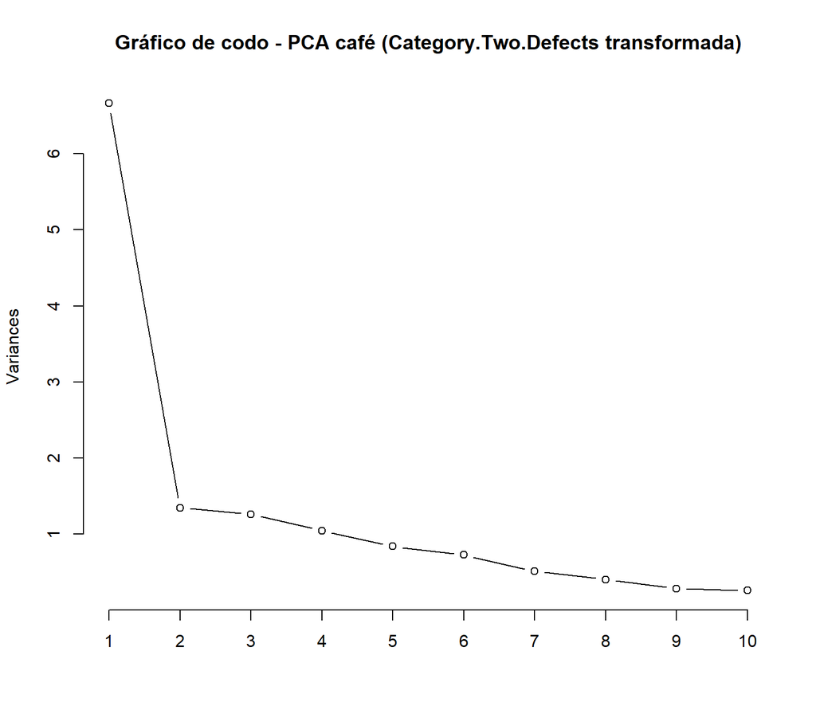

```r
screeplot(pca_t, type = "lines", main = "Gráfico de codo - PCA café (Category.Two.Defects transformada)")
```

```r
sum(pca_t$sdev^2 > 1)  # criterio de Kaiser
```

```
## [1] 4
```

# 3. Interpretación de las componentes

```r
round(pca_t$rotation[, 1:4], 3)
```

```
##                         PC1    PC2    PC3    PC4
## Aroma                -0.333 -0.102  0.067  0.023
## Flavor               -0.362 -0.100  0.067 -0.028
## Aftertaste           -0.359 -0.103  0.019 -0.026
## Acidity              -0.338 -0.116  0.103  0.033
## Body                 -0.337 -0.132  0.078 -0.090
## Balance              -0.346 -0.121  0.017 -0.041
## Uniformity           -0.234  0.458 -0.061  0.033
## Clean.Cup            -0.216  0.468 -0.179  0.054
## Sweetness            -0.223  0.533  0.007 -0.056
## Cupper.Points        -0.337 -0.138  0.033 -0.047
## Moisture              0.071  0.368  0.405  0.219
## Category.One.Defects  0.039 -0.043  0.535 -0.594
## Category.Two.Defects  0.074  0.117  0.652  0.094
## altitude_mean_meters -0.071 -0.200  0.248  0.754
```

### PC1 (47.6 % de la varianza) — “calidad sensorial general” (sin cambios)

- **Variables con mayor peso:** los siete puntajes de intensidad sensorial (Flavor −0.362, Aftertaste −0.359, Balance −0.346, Acidity −0.338, Cupper.Points −0.337, Body −0.337, Aroma −0.333), igual que en el análisis original.
- **Variables con comportamientos similares:** Uniformity (−0.234), Sweetness (−0.223), Clean.Cup (−0.216).
- **Variables que aparecen en sentidos opuestos:** ninguna con peso relevante — `Moisture` (0.071), `Category.One.Defects` (0.039), `Category.Two.Defects` (0.074, ya transformada) y `altitude_mean_meters` (−0.071) siguen siendo prácticamente nulas.
- **Significado:** idéntico al PC1 del análisis original — `Category.Two.Defects` no tenía peso en este eje, así que corregir su sesgo no lo toca en absoluto.

### PC3 (9.0 %) — “defectos y humedad” (lo que antes era PC2, ahora en tercer lugar)

- **Variables con mayor peso:** `Category.Two.Defects` (0.652, ya transformada) y `Category.One.Defects` (0.535).
- **Variables con comportamientos similares:** `Moisture` (0.405) y `altitude_mean_meters` (0.248) se suman con el mismo signo.
- **Variables que aparecen en sentidos opuestos:** ninguna con peso apreciable (`Clean.Cup` −0.179 es la más notoria, pero modesta).
- **Significado:** el bloque de “defectos físicos” del análisis original no desaparece — simplemente se reordena a la tercera posición en vez de la segunda, con una lectura casi idéntica (defectos y humedad, casi ortogonal a la calidad sensorial de PC1).

### PC4 (7.5 %) — “altitud, con defectos primarios más claramente opuestos”

- **Variables con mayor peso:** `altitude_mean_meters` (0.754), igual de dominante que en el análisis original (0.791).
- **Variables que aparecen en sentidos opuestos:** `Category.One.Defects` (−0.594) — más del doble de fuerte que en el análisis original (−0.237) — es la carga que más se acentúa con la transformación.
- **Variables con comportamientos similares:** `Moisture` (0.219, menor que el 0.545 original).
- **Significado:** el mismo eje agroclimático del análisis original, pero con la oposición altitud/humedad vs. defectos primarios bastante más marcada.

**En síntesis:** transformar únicamente `Category.Two.Defects` no elimina ninguna de las cuatro historias del análisis original (calidad sensorial, defectos físicos, consistencia/dulzura, altitud) — las reordena: el bloque de “defectos” pasa de PC2 a PC3, y el de “consistencia/dulzura” pasa de PC3 a PC2. PC1 permanece intacto en cualquier caso.

# 4. Matriz de dispersión de las componentes

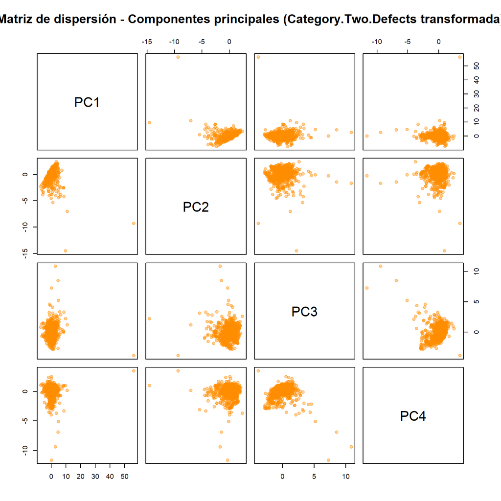

```r
k <- 4
pairs(pca_t$x[, 1:k],
      main = "Matriz de dispersión - Componentes principales (Category.Two.Defects transformada)",
      pch = 19, col = adjustcolor("darkorange", alpha.f = 0.4))
```

El patrón general no cambia frente al análisis original (sección 8 del informe principal): sigue sin haber agrupamientos discretos, la nube es continua en todos los pares de componentes. Lo que sí cambia, como muestra la sección 3.2 del informe principal, es que los dos lotes con más defectos ya no aparecen como los puntos más extremos de la componente que antes era PC2 (ahora PC3) — su posición dentro de la nube es mucho menos periférica.

# 5. Biplot (PC1 vs PC2)

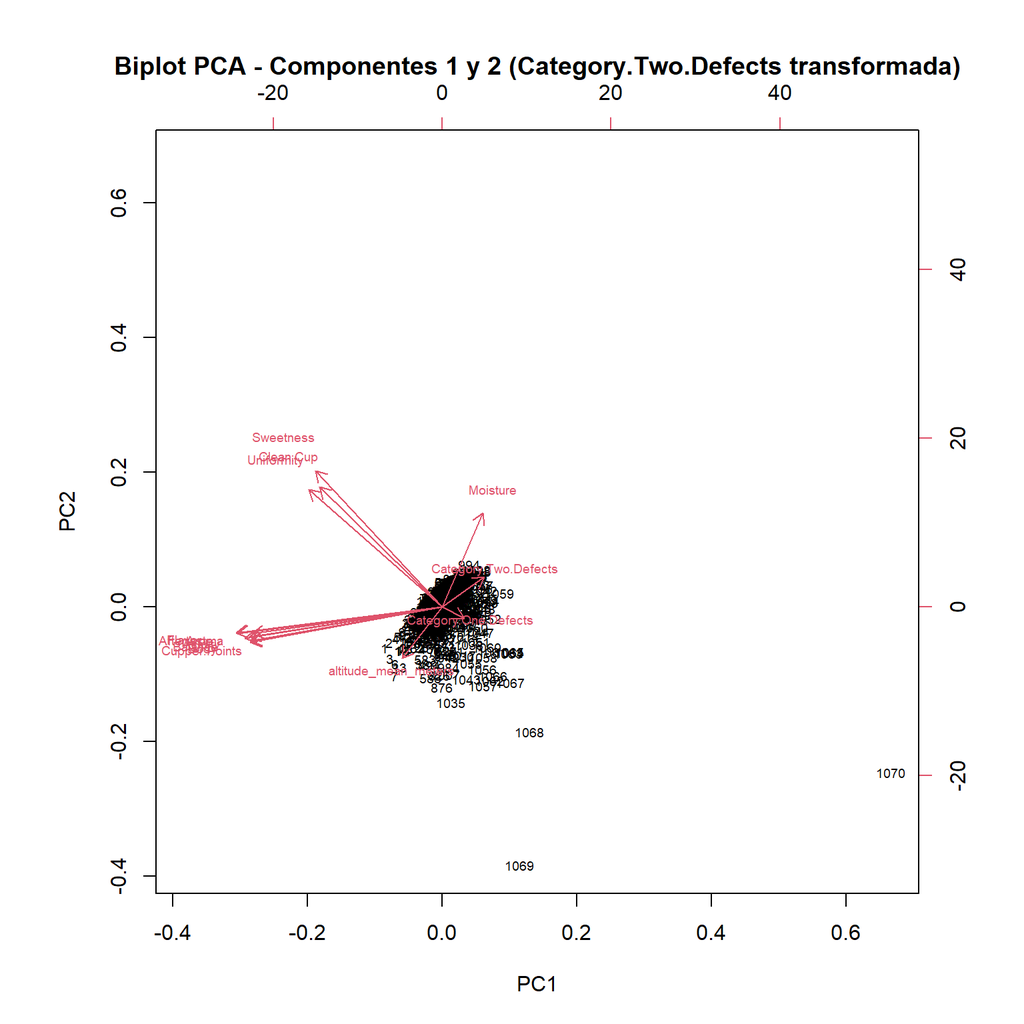

```r
biplot(pca_t, choices = c(1, 2), cex = 0.6,
       main = "Biplot PCA - Componentes 1 y 2 (Category.Two.Defects transformada)")
```

El haz de flechas sensoriales en PC1 no cambia frente al biplot original (sección 9 del informe principal). Lo que sí cambia es qué variables definen el eje vertical: aquí son `Sweetness`, `Clean.Cup` y `Uniformity` (antes era el bloque de defectos) — visualmente coherente con que PC2 pasó a representar consistencia/dulzura de taza en vez de defectos físicos.

# 6. Qué faltaría si se adopta esta versión

Este documento cubre PCA (secciones 5–9 del informe principal). Si se decide adoptar la versión transformada como oficial, faltaría:

- **Kernel PCA, t-SNE y UMAP:** se ejecutan con el mismo código del informe principal (secciones 10–13), reemplazando `datos` por `datos_t` antes de estandarizar. Deberían re-ejecutarse y revisarse antes de presentarlos, no asumir que el resultado visual es idéntico.
- **Sección 14 (comparación) y sección 15 (conclusiones):** habría que actualizar cuál componente representa cada historia — la de “defectos” pasa a ser PC3, no PC2, y PC2 pasa a leerse como “consistencia y dulzura de taza”.
- **Diapositivas:** la tabla de cargas y cualquier mención textual a “PC2 = defectos” tendría que decir “PC3 = defectos y humedad” y “PC2 = consistencia/dulzura de taza”.